# Tidy text analysis, part 2: sentiment analysis

## Using TidyText to perform sentiment analysis

Now we will create a ‘words’ vector that goes through the standard tidytext process of uploading a text file, creating a dataframe of words and row numbers, and tokenizing the words in the text file.

```r
alice_words$word[5:25]
```

```
 [1] "the"       "rabbit"    "hole_"     "alice"     "was"       "beginning" "to"
 [8] "get"       "very"      "tired"     "of"        "sitting"   "by"        "her"
[15] "sister"    "on"        "the"       "bank"      "and"       "of"        "having"
```

Next you invoke the ‘inner_join’ function which is essentially a way of conflating (or comparing) a data set against another. This is much easier to accomplish when the data is in tidy format. Here we are joining the text data from Lewis Carrol’s *Alice in Wonderland* with a dictionary of sentiment words that assigns positive or negative values to each word.

```r
alice_words_sentiment <- inner_join(alice_words,
                              get_sentiments("bing")) %>%
  count(file, index = round(line_number/ max(line_number) * 100 / 5) * 5, sentiment) %>%
  spread(sentiment, n, fill = 0) %>%
  mutate(net_sentiment = positive - negative)
```

Did you notice the `get_sentiments` function? What is happening is that you are calling an `inner_join` function that includes an instruction to compare the tidy words tibble to a sentiment dictionary called “bing.” Let’s have a look at this.

| word | sentiment |
| --- | --- |
| 2-faces | negative |
| abnormal | negative |
| abolish | negative |
| abominable | negative |
| abominably | negative |
| abominate | negative |
| abomination | negative |
| abort | negative |
| aborted | negative |
| aborts | negative |

[output cut: 990 more lines]

We get a binary sentiment result (positive or negative). Another useful dictionary (probably better for more complex or historical texts) is “aFinn”.

| word | value |
| --- | --- |
| abandon | -2 |
| abandoned | -2 |
| abandons | -2 |
| abducted | -2 |
| abduction | -2 |
| abductions | -2 |
| abhor | -3 |
| abhorred | -3 |
| abhorrent | -3 |
| abhors | -3 |

[output cut: 990 more lines]

| word | sentiment |
| --- | --- |
| abacus | trust |
| abandon | fear |
| abandon | negative |
| abandon | sadness |
| abandoned | anger |
| abandoned | fear |
| abandoned | negative |
| abandoned | sadness |
| abandonment | anger |
| abandonment | fear |

[output cut: 990 more lines]

Silge and Robinson provide a useful flowchart of how this works.

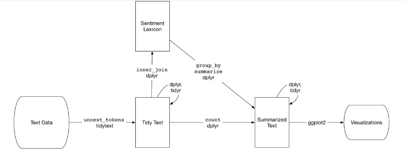

tidy-sentiment.png

Back to our results: Using the ggplot library, we can visualise the results.

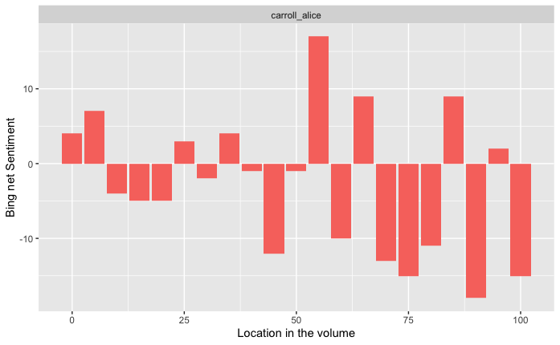

Let’s make this interesting by comparing these results to another children’s author from our corpus.

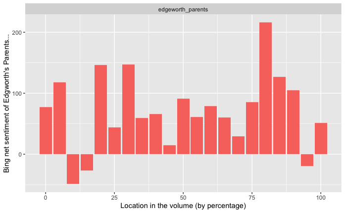

Clearly Lewis Carrol’s *Alice* is more sinister on the single-word level. Let’s break down the Carrol results into more understandable graphs.

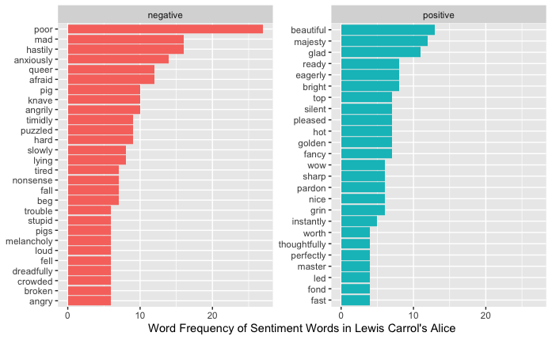

| word | lexicon |
| --- | --- |
| miss | custom |
| mock | custom |
| like | custom |
| a | SMART |
| a's | SMART |
| able | SMART |
| about | SMART |
| above | SMART |
| according | SMART |
| accordingly | SMART |

[output cut: 990 more lines]

Let try this with another sentiment dictionary.

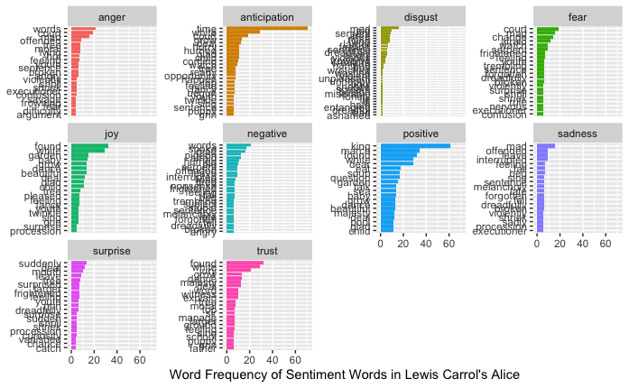

```r
alice.nrc_word_counts %>%
  group_by(sentiment) %>%
  top_n(20) %>%
  ungroup() %>%
  mutate(word = reorder(word, n)) %>%
  ggplot(aes(word, n, fill = sentiment)) +
  geom_col(show.legend = FALSE) +
  facet_wrap(~sentiment, scales = "free_y") +
  labs(y = "Word Frequency of Sentiment Words in Lewis Carrol's Alice",
       x = NULL) +
  coord_flip()
```

Here we have different categories of sentiment words, and it seems to be more accurate than the bing calculations.

We can also use the tidy `filter()` function to focus on a specific category of sentiment.

| word | sentiment | n |
| --- | --- | --- |
| found | joy | 32 |
| white | joy | 29 |
| good | joy | 27 |
| garden | joy | 15 |
| baby | joy | 14 |
| beautiful | joy | 13 |
| dance | joy | 13 |
| grow | joy | 13 |
| deal | joy | 12 |
| child | joy | 11 |

[output cut: 83 more lines]

You can use the code below to combine the two sentiment dictionary results in an overall trajectory.

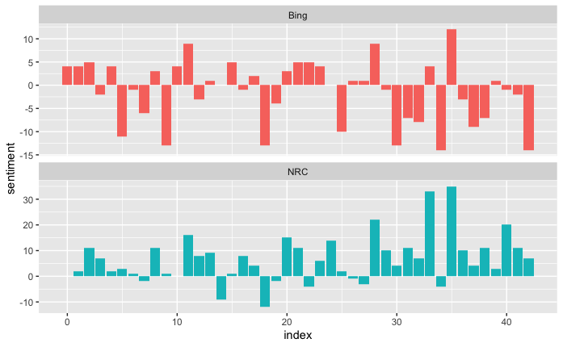

As you can see the bing dictionary generally scores the text more negatively than the nrc. Let’s now compare this to Edgeworth.

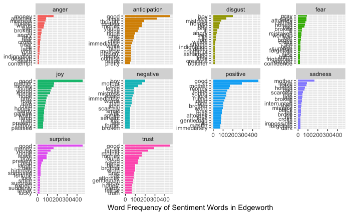

```r
edg.nrc_word_counts %>%
  group_by(sentiment) %>%
  top_n(20) %>%
  ungroup() %>%
  mutate(word = reorder(word, n)) %>%
  ggplot(aes(word, n, fill = sentiment)) +
  geom_col(show.legend = FALSE) +
  facet_wrap(~sentiment, scales = "free_y") +
  labs(y = "Word Frequency of Sentiment Words in Edgeworth",
       x = NULL) +
  coord_flip()
```

Another way to re-orient the sentiment results is to create a word cloud. Sometimes these can be useful for assessing the total weight of positivity or negativity in a text.

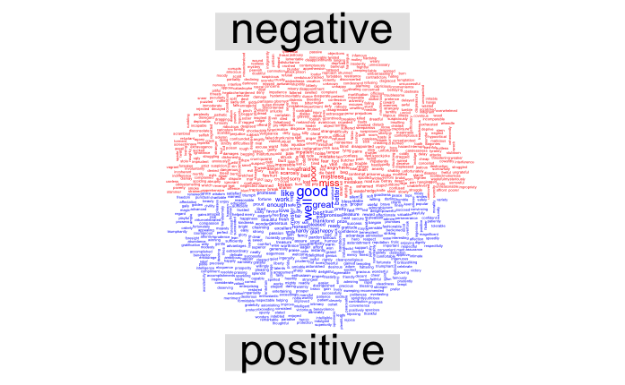

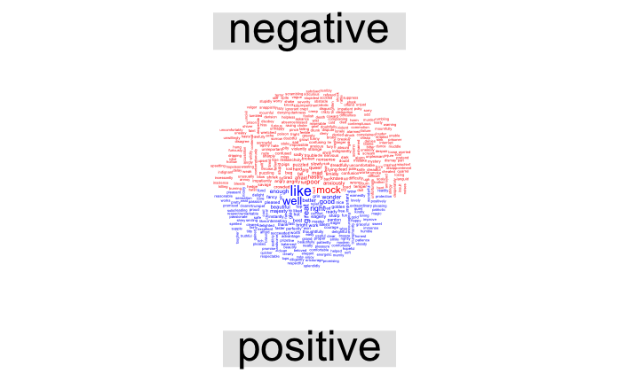

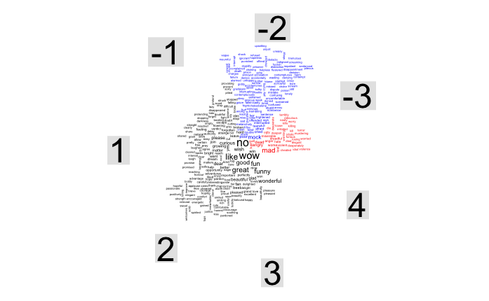

```r
alice_words %>%
  inner_join(get_sentiments("afinn")) %>%
  count(word, value, sort = TRUE) %>% # notice here that you're calling on a different observation ("value") instead of the "sentiment" in the previous example: that's due to the tibble structure of the dictionary
  acast(word ~ value, value.var = "n", fill = 0) %>%
  comparison.cloud(max.words = 1000, scale = c(1,.25),
                   random.order = FALSE,
                   colors = c("red", "blue"))
```

### Accessing more context: 2-n gram frequencies

| word1 | word2 | n |
| --- | --- | --- |
| NA | NA | 105 |
| mock | turtle | 52 |
| march | hare | 30 |
| white | rabbit | 19 |
| poor | alice | 10 |
| alice | looked | 8 |
| alice | replied | 8 |
| beautiful | soup | 8 |
| soo | oop | 7 |
| cried | alice | 6 |

[output cut: 990 more lines]

| word1 | word2 | word3 | n |
| --- | --- | --- | --- |
| NA | NA | NA | 189 |
| beau | ootiful | soo | 4 |
| ootiful | soo | oop | 4 |
| white | kid | gloves | 4 |
| cats | eat | bats | 3 |
| _a | mad | tea | 2 |
| alice | cautiously | replied | 2 |
| alice | hastily | replied | 2 |
| beautiful | beautiful | soup | 2 |
| dear | cried | alice | 2 |

[output cut: 280 more lines]

### Using bigrams to provide contextual sentiment

| word1 | word2 | n |
| --- | --- | --- |
| not | a | 7 |
| not | like | 6 |
| not | said | 6 |
| not | the | 6 |
| not | at | 5 |
| not | could | 5 |
| not | to | 4 |
| not | gone | 3 |
| not | join | 3 |
| not | would | 3 |

[output cut: 63 more lines]

| word2 | value | n |
| --- | --- | --- |
| like | 2 | 6 |
| join | 1 | 3 |
| allow | 1 | 1 |
| easy | 1 | 1 |
| escape | -1 | 1 |
| feeling | 1 | 1 |
| help | 2 | 1 |
| mad | -3 | 1 |
| wish | 1 | 1 |

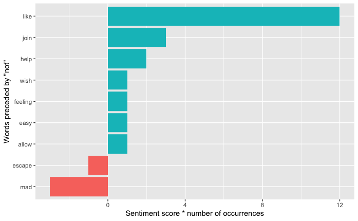

Now let’s add to this by accounting for negation words.

```r
negated_words <- bigrams_sep %>%
  filter(word1 %in% negation_words) %>%
  inner_join(AFINN, by = c(word2 = "word")) %>%
  count(word1, word2, score, sort = TRUE) %>%
  ungroup()
```

[output not shown]

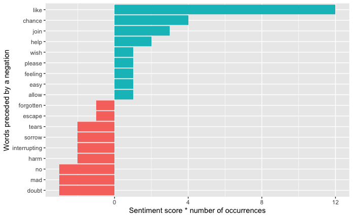

## Exercise 3

1. Load your own texts (either from your our corpus or from a digital repository like or Project Gutenberg).
2. Posit a new question–or questions–about what you would like to investigate further.
3. Modify a code block(s) from the R Notebook to answer your question.

## Publish your results

If you are interested in learning more about R and corpus linguistics, in addition to Silge and Robinson and Jockers, you could also consult R. H. Baayen’s *Analyzing Linguistic Data: A practical introduction to statistics* (Cambridge UP, 2008) and Stefan Gries’s *Quantitative Corpus Linguistics with R*, 2nd ed. (Routledge, 2017).

Some good web resources include Jeff Rydberg-Cox’s [Introduction to R](https://daedalus.umkc.edu/StatisticalMethods/index.html) and David Silge and Julia Robinson’s [*Text Mining with R*](https://www.tidytextmining.com/). Also be sure to examine the [CRAN R Documentation site](https://cran.r-project.org/doc/manuals/R-intro.html).